# DV_RProject3

Zareen Khayrattee, Kayne Khoury, Juanito Taveras

October 14, 2015

# Extraction, Transformation, Loading

To fix our data so it can be loaded into Oracle correctly, we first replaced the periods in our column rows with underscores.

```
> names(df) <-gsub("\\.+", "_", names(df))
```

We then, set our measures appropriately:

```
> measures <- c("Year", "Deaths_less_than_1_month", "Deaths_1_to_59_months", "Deaths_0_to_4_years")
```

We created our re-formatted csv, then created our SQL concatenation

```
> tableName <- gsub(" +", "_", gsub("[^A-z, 0-9, ]", "", gsub(".csv", "", file_path)))
sql <- paste("CREATE TABLE", tableName, "Respiratory_Infections")
if( length(measures) > 1 || ! is.na(dimensions)) {
  for(d in dimensions) {
    sql <- paste(sql, paste(d, "varchar2(4000),\n"))
  }
}
if( length(measures) > 1 || ! is.na(measures)) {
  for(m in measures) {
    if(m != tail(measures, n=1)) sql <- paste(sql, paste(m, "number(38,4),\n"))
    else sql <- paste(sql, paste(m, "number(38,4)\n"))
  }
}
sql <- paste(sql, ");")
cat(sql)
```

And pasted it into SQL developer. We ran this script, then imported our reformatted CSV to create the table.

```r
require("ggplot2")
require("ggthemes")
require("gplots")
require("grid")
require("RCurl")
require("reshape2")
require("tableplot")
require("tidyr")
require("dplyr")
require("jsonlite")
require("extrafont")
require("lubridate")
```

## The effects of prematurity on newborn infants

The workflow is designed to explore the effects of prematurity in newborns across the globe. Our visualization tells us that for countries with more than 100,000 total deaths for all years, the United States had both the highest percentage aged 1-27 days, and the highest percentage that died due to prematuriy. This is a surprising find given contradiction to the commonly held notion that infant mortality rates are the lowest amongst developed, Westernized nations.

```r
source("../02 Data Wrangling/Blending_P2.R",echo=TRUE)
```

```
##
## > premature_df <- data.frame(fromJSON(getURL(URLencode("129.152.144.84:5001/rest/native/?query=\"select * from premature\""),
## +     httpheader = c(DB .... [TRUNCATED]
##
## > infections_df <- data.frame(fromJSON(getURL(URLencode("129.152.144.84:5001/rest/native/?query=\"select * from infected\""),
## +     httpheader = c(DB .... [TRUNCATED]
##
## > trauma_df <- data.frame(fromJSON(getURL(URLencode("129.152.144.84:5001/rest/native/?query=\"select * from trauma\""),
## +     httpheader = c(DB = "jd ..." ... [TRUNCATED]
##
## > join_df <- inner_join(trauma_df, premature_df, by = c("COUNTRY",
## +     "YEAR")) %>% arrange(COUNTRY, YEAR)
##
## > join_df_2 <- left_join(join_df, infections_df, by = c("COUNTRY",
## +     "YEAR")) %>% arrange(COUNTRY, YEAR)
##
## > trauma <- join_df_2 %>% group_by(COUNTRY) %>% summarise(total = sum(TRAUMA_TOTAL) +
## +     sum(PREM_TOTAL) + sum((RESP_TOTAL)), pcnt_trauma = (sum(T .... [TRUNCATED]
##
## > vis_df <- trauma %>% filter(total > 1e+05) %>% head(10)
##
## > vis_df[(c("COUNTRY", "pcnt_prematurity"))]
## Source: local data frame [10 x 2]
##
##                       COUNTRY pcnt_prematurity
## 1    United States of America         78.90490
## 2                    Colombia         55.87289
## 3                      Brazil         53.75082
## 4          Russian Federation         56.22072
## 5                    Viet Nam         48.86665
## 6                      Turkey         51.05821
## 7                     Morocco         43.60101
## 8                       Nepal         31.22403
## 9  Iran (Islamic Republic of)         48.27585
## 10                   Zimbabwe         34.93868
##
## > ggplot(data = vis_df, mapping = aes(x = pcnt_0_to_27_days,
## +     y = total, color = pcnt_prematurity)) + labs(title = "2000-2013") +
## +     facet_w .... [TRUNCATED]
```

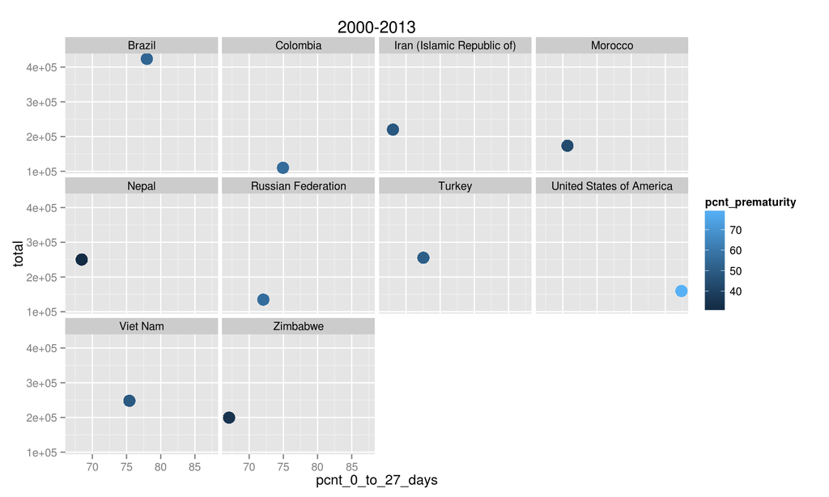

## Workflow 2

In the first graph of this workflow, which is uses facet wrap by year, it’s hard to find a pattern.As a whole though, from 2000 to 2013, the deaths seem to go from being conentrated more on the top right portion of the graph, where both percentages of death are highest, to being more evenly distributed and less concentrated. This may signify that as a whole, deaths caused by trauma and prematurity in babies 0-27 days have been on the decline.

```
##
## > premature_df <- data.frame(fromJSON(getURL(URLencode("129.152.144.84:5001/rest/native/?query=\"select * from premature\""),
## +     httpheader = c(DB .... [TRUNCATED]
##
## > infections_df <- data.frame(fromJSON(getURL(URLencode("129.152.144.84:5001/rest/native/?query=\"select * from infected\""),
## +     httpheader = c(DB .... [TRUNCATED]
##
## > trauma_df <- data.frame(fromJSON(getURL(URLencode("129.152.144.84:5001/rest/native/?query=\"select * from trauma\""),
## +     httpheader = c(DB = "jd ..." ... [TRUNCATED]
##
## > names(premature_df)
## [1] "COUNTRY"             "YEAR"                "PREM_0_TO_27_DAYS"
## [4] "PREM_1_TO_59_MONTHS" "PREM_TOTAL"
##
## > names(infections_df)
## [1] "COUNTRY"             "YEAR"                "RESP_0_TO_27_DAYS"
## [4] "RESP_1_TO_59_MONTHS" "RESP_TOTAL"
##
## > names(trauma_df)
## [1] "COUNTRY"               "YEAR"                  "TRAUMA_0_TO_27_DAYS"
## [4] "TRAUMA_1_TO_59_MONTHS" "TRAUMA_TOTAL"
##
## > join_df <- inner_join(trauma_df, premature_df, by = c("COUNTRY",
## +     "YEAR")) %>% arrange(COUNTRY, YEAR)
##
## > join_df %>% mutate(Percent_trauma = TRAUMA_0_TO_27_DAYS/TRAUMA_TOTAL,
## +     Percent_prem = PREM_0_TO_27_DAYS/PREM_TOTAL) %>% filter(TRAUMA_TOTAL +  .... [TRUNCATED]
```

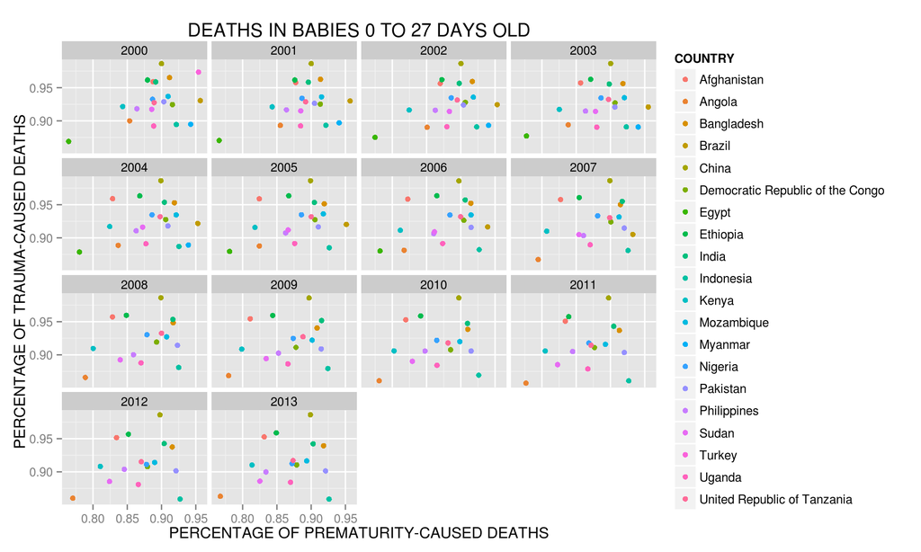

```
##
## > join_df %>% mutate(Percent_trauma = TRAUMA_0_TO_27_DAYS/TRAUMA_TOTAL,
## +     Percent_prem = PREM_0_TO_27_DAYS/PREM_TOTAL) %>% filter(TRAUMA_TOTAL +  .... [TRUNCATED]
```

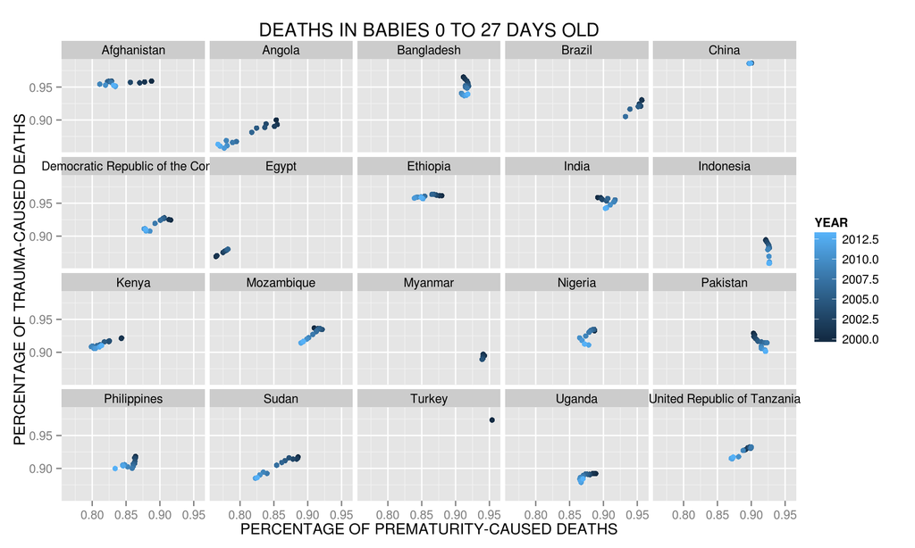

```r
source("../02 Data Wrangling/plot1_inner.R",echo=TRUE)
```

## Workflow 3

The third workflow was created by blending three data sets together: Worldwide deaths in children under five that died from premature, respiratory, and trauma causes. We then filtered the data to show only deaths from INdia and China, two countries that had remarkably high deaths from respiratory infections.

We can now see that from the year 2000 - 2013 in India, Respiratory and Trauma deaths declined significantly, but premature deaths barely decreased at all. In China though, all three types of deaths declined simulataneously.

You can clearly see that the health issue of premature deaths in India has not been tackled to the extent that respiratory and trauama deaths have, which could be indicative of a societal problem that needs to be addressed immediately. China was able to solve this issue and India was not, which is even more interesting.

```r
source("../02 Data Wrangling/Blending_P3.R", echo=TRUE)
```

```
##
## > premature_df <- data.frame(fromJSON(getURL(URLencode("129.152.144.84:5001/rest/native/?query=\"select * from premature\""),
## +     httpheader = c(DB .... [TRUNCATED]
##
## > infections_df <- data.frame(fromJSON(getURL(URLencode("129.152.144.84:5001/rest/native/?query=\"select * from infected\""),
## +     httpheader = c(DB .... [TRUNCATED]
##
## > trauma_df <- data.frame(fromJSON(getURL(URLencode("129.152.144.84:5001/rest/native/?query=\"select * from trauma\""),
## +     httpheader = c(DB = "jd ..." ... [TRUNCATED]
##
## > join_df <- full_join(trauma_df, premature_df, by = c("COUNTRY",
## +     "YEAR")) %>% arrange(COUNTRY, YEAR)
##
## > join_df_2 <- left_join(join_df, infections_df, by = c("COUNTRY",
## +     "YEAR")) %>% arrange(COUNTRY, YEAR)
##
## > join_df_3 <- right_join(join_df, infections_df, by = c("COUNTRY",
## +     "YEAR")) %>% arrange(COUNTRY, YEAR)
##
## > join_df_2 <- join_df_2 %>% filter(COUNTRY %in% c("India",
## +     "China"))
##
## > ggplot() + coord_cartesian() + scale_x_continuous() +
## +     scale_y_continuous() + facet_wrap(~COUNTRY) + labs(title = "Total Infant Deaths in Indi ..." ... [TRUNCATED]
```

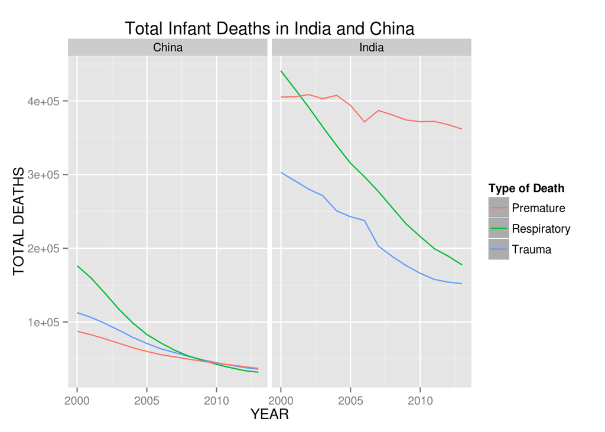

## Summary

```r
source("../01 Data/Summary.R", echo=TRUE)
```

```
##
## > premature_df <- data.frame(fromJSON(getURL(URLencode("129.152.144.84:5001/rest/native/?query=\"select * from premature\""),
## +     httpheader = c(DB .... [TRUNCATED]
##
## > infections_df <- data.frame(fromJSON(getURL(URLencode("129.152.144.84:5001/rest/native/?query=\"select * from infected\""),
## +     httpheader = c(DB .... [TRUNCATED]
##
## > trauma_df <- data.frame(fromJSON(getURL(URLencode("129.152.144.84:5001/rest/native/?query=\"select * from trauma\""),
## +     httpheader = c(DB = "jd ..." ... [TRUNCATED]
##
## > join_df <- full_join(trauma_df, premature_df, by = c("COUNTRY",
## +     "YEAR")) %>% arrange(COUNTRY, YEAR)
##
## > join_df_2 <- left_join(join_df, infections_df, by = c("COUNTRY",
## +     "YEAR")) %>% arrange(COUNTRY, YEAR)
##
## > summary(join_df_2)
##                 COUNTRY          YEAR      TRAUMA_0_TO_27_DAYS
##  Afghanistan        :  14   Min.   :2000   Min.   :     0.0
##  Albania            :  14   1st Qu.:2003   1st Qu.:    26.0
##  Algeria            :  14   Median :2006   Median :   250.5
##  Andorra            :  14   Mean   :2006   Mean   :  4177.9
##  Angola             :  14   3rd Qu.:2010   3rd Qu.:  2291.2
##  Antigua and Barbuda:  14   Max.   :2013   Max.   :290471.0
##  (Other)            :2632
##  TRAUMA_1_TO_59_MONTHS  TRAUMA_TOTAL    PREM_0_TO_27_DAYS
##  Min.   :    0.0       Min.   :     0   Min.   :     0.0
##  1st Qu.:    2.0       1st Qu.:    29   1st Qu.:    70.8
##  Median :   24.0       Median :   272   Median :   519.5
##  Mean   :  306.8       Mean   :  4485   Mean   :  5473.0
##  3rd Qu.:  215.5       3rd Qu.:  2630   3rd Qu.:  3576.0
##  Max.   :12512.0       Max.   :302983   Max.   :368519.0
##
##  PREM_1_TO_59_MONTHS   PREM_TOTAL       RESP_0_TO_27_DAYS
##  Min.   :    0.0     Min.   :     0.0   Min.   :    0.0
##  1st Qu.:    5.0     1st Qu.:    78.0   1st Qu.:    3.0
##  Median :   56.0     Median :   599.5   Median :   54.5
##  Mean   :  660.7     Mean   :  6133.7   Mean   :  954.9
##  3rd Qu.:  447.0     3rd Qu.:  4021.8   3rd Qu.:  487.2
##  Max.   :43934.0     Max.   :408547.0   Max.   :64343.0
##
##  RESP_1_TO_59_MONTHS   RESP_TOTAL
##  Min.   :     0.0    Min.   :     0
##  1st Qu.:    15.0    1st Qu.:    20
##  Median :   287.5    Median :   345
##  Mean   :  5542.1    Mean   :  6497
##  3rd Qu.:  3211.2    3rd Qu.:  3748
##  Max.   :376482.0    Max.   :440825
##
```

# Subset

```r
source("../01 Data/Subset.R", echo=TRUE)
```

```
##
## > premature_df <- data.frame(fromJSON(getURL(URLencode("129.152.144.84:5001/rest/native/?query=\"select * from premature\""),
## +     httpheader = c(DB .... [TRUNCATED]
##
## > infections_df <- data.frame(fromJSON(getURL(URLencode("129.152.144.84:5001/rest/native/?query=\"select * from infected\""),
## +     httpheader = c(DB .... [TRUNCATED]
##
## > trauma_df <- data.frame(fromJSON(getURL(URLencode("129.152.144.84:5001/rest/native/?query=\"select * from trauma\""),
## +     httpheader = c(DB = "jd ..." ... [TRUNCATED]
##
## > join_df <- full_join(trauma_df, premature_df, by = c("COUNTRY",
## +     "YEAR")) %>% arrange(COUNTRY, YEAR)
##
## > join_df_2 <- left_join(join_df, infections_df, by = c("COUNTRY",
## +     "YEAR")) %>% arrange(COUNTRY, YEAR)
##
## > sst <- join_df_2 %>% filter(TRAUMA_TOTAL > 1e+05)
##
## > head(sst)
##   COUNTRY YEAR TRAUMA_0_TO_27_DAYS TRAUMA_1_TO_59_MONTHS TRAUMA_TOTAL
## 1   China 2000              111118                  1543       112661
## 2   China 2001              104781                  1453       106234
## 3   India 2000              290471                 12512       302983
## 4   India 2001              279486                 12163       291649
## 5   India 2002              267964                 12177       280142
## 6   India 2003              259343                 12064       271407
##   PREM_0_TO_27_DAYS PREM_1_TO_59_MONTHS PREM_TOTAL RESP_0_TO_27_DAYS
## 1             78608                8735      87343             29646
## 2             74457                8264      82721             28117
## 3            361258               43934     405192             64343
## 4            363355               42214     405569             60894
## 5            366725               41822     408547             57566
## 6            361944               40987     402931             54752
##   RESP_1_TO_59_MONTHS RESP_TOTAL
## 1              146734     176380
## 2              131566     159682
## 3              376482     440825
## 4              355439     416333
## 5              333685     391252
## 6              310094     364847
```